Sphingosine-1-Phosphate and

Its Signal Modulators Alleviate

Psoriasis-Like Dermatitis:

Preclinical and Clinical Evidence

and Possible Mechanisms

Liu Liu <sup>1,2</sup>†, Jiao Wang <sup>1,2</sup>†, Hong-jin Li <sup>3</sup>, Shuo Zhang <sup>1,2</sup>, Meng-zhu Jin <sup>4</sup>, Si-ting Chen <sup>1,2</sup>,

Xiao-ying Sun <sup>3</sup>, Ya-qiong Zhou <sup>3</sup>, Yi Lu <sup>1</sup>, Dan Yang <sup>1,2</sup>, Ying Luo <sup>3</sup>, Yi Ru <sup>1,2</sup>, Bin Li <sup>3,5</sup>*

and Xin Li <sup>1,3</sup>*

1 Department of Dermatology, Yueyang Hospital of Integrated Traditional Chinese and Western Medicine, Shanghai University

of Traditional Chinese Medicine, Shanghai, China, <sup>2</sup>Shanghai University of Traditional Chinese Medicine, Shanghai, China,

3 Institute of Dermatology, Shanghai Academy of Traditional Chinese Medicine, Shanghai, China, 4 Department of

Dermatology, The First Hospital of Jiaxing and The Afﬁliated Hospital of Jiaxing University, Jiaxing, China, <sup>5</sup>Department of

Dermatology, Shanghai Skin Disease Hospital, Shanghai, China

Background: Psoriasis is an autoimmune skin disease associated with lipid metabolism.

Sphingosine-1-phosphate (S1P) is a bioactive lipid that plays a key role in the

development of autoimmune diseases. However, there is currently a lack of

comprehensive evidence of the effectiveness of S1P on psoriasis.

Objective: To assess the efﬁcacy and possible mechanism of S1P and its signal

modulators in the treatment of psoriasis-like dermatitis.

Methods: Six databases were searched through May 8, 2021, for studies reporting S1P

and its signal modulators. Two reviewers independently extracted information from the

enrolled studies. Methodological quality was assessed using SYRCLE’s risk of bias tool.

RevMan 5.3 software was used to analyze the data. For clinical studies, the Psoriasis Area

and Severity Index score were the main outcomes. For preclinical studies, we clariﬁed the

role of S1P and its regulators in psoriasis in terms of phenotype and mechanism.

Results: One randomized double-blind placebo-controlled trial and nine animal studies

were included in this study. The pooled results showed that compared with control

treatment, S1P receptor agonists [mean difference (MD): −6.80; 95% conﬁdence interval

(CI): −8.23 to −5.38; p<0.00001], and sphingosine kinase 2 inhibitors (MD: −0.95; 95%

CI: −1.26 to −0.65; p<0.00001) alleviated psoriasis-like dermatitis in mice. The

mechanism of S1P receptor agonists in treating psoriasis might be related to a decrease

in the number of white blood cells, topical lymph node weight, interleukin-23 mRNA levels,

and percentage of CD3<sup>+</sup>T cells (p<0.05). Sphingosine kinase 2 inhibitors ameliorated

psoriasis in mice, possibly by reducing spleen weight and cell numbers (p<0.05).

Edited by:

Janine Lamb,

The University of Manchester,

United Kingdom

Reviewed by:

Amira Kamil Mohammed,

University of Baghdad, Iraq

Francesco Poti,

University of Parma, Italy

*Correspondence:

Xin Li

13661956326@163.com

Bin Li

18930568129@163.com

†These authors have contributed

equally to this work

Specialty section:

This article was submitted to

Autoimmune and

Autoinﬂammatory Disorders,

a section of the journal

Frontiers in Immunology

Received: 16 August 2021

Accepted: 06 December 2021

Published: 21 December 2021

Citation:

Liu L, Wang J, Li H-j, Zhang S,

Jin M-z, Chen S-t, Sun X-y,

Zhou Y-q, Lu Y, Yang D, Luo Y,

Ru Y, Li B and Li X (2021)

Sphingosine-1-Phosphate and Its

Signal Modulators Alleviate Psoriasis-

Like Dermatitis: Preclinical and Clinical

Evidence and Possible Mechanisms.

Front. Immunol. 12:759276.

doi: 10.3389/fimmu.2021.759276

SYSTEMATIC REVIEW

published: 21 December 2021

doi: 10.3389/fimmu.2021.759276

Conclusions: S1P receptor agonists and sphingosine kinase 2 inhibitors could be

potential methods for treating psoriasis by decreasing immune responses and

inﬂammatory factors.

Keywords: preclinical evidence, psoriasis, S1P receptor (S1PR) agonists, sphingosine-1-phosphate, sphingosine-

1-phosphate signaling modulators, sphingosine kinase 2 inhibitors, systematic review and meta-analysis

INTRODUCTION

Psoriasis is characterized by demarcated erythema covered with

silvery-white scales and often accompanied by varying degrees of

itching (1). The global prevalence of psoriasis reportedly varies

from 0% to 2.1% in children and 0.91% to 8.5% in adults (2). In

addition to the high prevalence of psoriasis, comorbidities such

as metabolic syndrome (3), hyperuricemia (4), chronic

obstructive pulmonary disease (5), and cardiovascular disease

(6) cause great burdens for patients with psoriasis. Psoriasis is

considered an autoimmune skin disease, and the classic

pathogenesis involves an interleukin-17/interleukin-23 (IL-17/

IL-23) immune axis disorder. Therefore, biological agents

targeting the IL-17/IL-23 signaling axis have been developed,

including IL-17 inhibitors, interleukin 12 (IL-12)/IL-23

inhibitors, and tumor necrosis factor-alpha (TNF-a)

antagonists (7). Compared with traditional therapies, although

biological agents have good curative effects, the risk of recurrence

is increased. A recently published meta-analysis showed that

anti-IL-23 drugs are likely to cause a series of immunological and

non-immunological adverse events, while their long-term use

may cause mental illness (8). Therefore, dermatologists are

always seeking better treatment options.

Since several studies have reported that patients with psoriasis

have comorbid dysfunctional lipid metabolism (9, 10),

dermatologists have developed great interest in studying lipid

metabolism in patients with psoriasis. S1P is a bioactive lipid

produced by the metabolism of sphingolipids and generated by

another sphingolipid metabolite, ceramidase (11, 12). Extracellular

S1PisrecognizedbyﬁveGprotein-coupledreceptors,S1Preceptors

(S1PRs) 1–5, to regulate various biological processes such as cell

growth, differentiation, survival, and vascular and epithelial

integrity. S1P is synthesized by two sphingosine kinase subtypes 1

and 2 (SPHK1 and SPHK2) and cleaved by S1P lyase, S1P

phosphatase 1, and S1P phosphatase 2 (13). S1P signaling

reportedly plays a pivotal role in the development of autoimmune

diseases. In 2010, two phase III clinical studies published in The

New England Journal of Medicine reported that ﬁngolimod, an

S1PR agonist, was more effective than interferon inthe treatment of

multiple sclerosis and reduced the recurrence rate by more than

50% (14). In 2018, it became the only multiple sclerosis drug

approved to treat children. In the brains of patients with multiple

sclerosis, S1PR1 and SIPR3 levels are signiﬁcantly increased (15); in

patients with psoriasis, the serum S1P concentration is also

signiﬁcantly increased (16). A phase II trial showed that

ponesimod, a drug targeting S1P signaling, has therapeutic

potential for psoriasis (17). Compared with the classical treatment

of psoriasis, both immunosuppressants and biologics can aggravate

metabolic disorders in patients with psoriasis, and S1P signaling

pathway modulators may be a new treatment for psoriasis (18).

However, the efﬁcacy and mechanisms of S1P and its signaling

modulators in psoriasis have not been fully elucidated. Hence, here

we reviewed previous literature, including clinical and preclinical

studies on treatment of psoriasis with S1P and its signaling

modulators and quantitatively analyzed their therapeutic effects.

Furthermore, we quantitatively and qualitatively analyzed the

possible therapeutic targets in terms of phenotype and mechanism.

METHODS

Literature Search Strategy

The PubMed, Embase, Cochrane, Chinese National Knowledge

Infrastructure (CNKI), China Biology Medicine disc (CBMdisc),

and Wan Fang databases were electronically searched for

relevant articles published through May 8, 2021. A

combination of subjects and free words was used for the

search. Studies reporting the role of S1P or S1P signaling

modulators in animal models of psoriasis were identiﬁed. The

search terms included “psoriasis”, “S1P”, “sphingosine-1-

phosphate”, “ﬁngolimod”, and “animal”. These terms were also

translated into Chinese and used to search the Chinese databases.

The OpenGery database (http://www.opengrey.eu/), Chinese

Clinical Trial Registry (http://www.chictr.org.cn/), and

ClinicalTrials.gov (https://clinicaltrials.gov/) databases were

also searched. This review is conducted in line with the

Preferred Reporting Items for Systematic Reviews and Meta-

Analysis (PRISMA) guidelines (19).

Study Selection

Any studies that met the following criteria were included in this

systematic review: (1) randomized controlled trials comparing

S1P or S1P signaling modulators with any other drugs; (2)

psoriasis animal model; and (3) interventions including S1P or

S1P signaling modulators. The control conditions were the same

amount of non-functional liquid or no treatment. The exclusion

criteria were as follows: (1) reviews, case reports, and

observational studies; (2) studies without an in vivo model; (3)

studies without a control group; and (4) duplicate articles. Two

reviewers (H.-J.L. and Y.-Q.Z.) independently screened the titles

and abstracts according to the inclusion and exclusion criteria.

Any differences in opinions were resolved through discussion.

Data Extraction

following information: (1) ﬁrst author and publication year;

(2) animal species, age (weeks), sex; (3) type of psoriasis model;

(4) type of intervention, including different S1P-related drugs,

control drugs, and administration route; and (5) main outcome

measures. Data are presented as mean ± standard deviation. If

the data were not provided in the study, we attempted to

contact the authors for the original data or used the publicly

available WebPlotDigitizer 4.2 (20) (https://automeris.io/

WebPlotDigitizer) to extract the data (21).

Quality Assessment

SYRCLE’s risk of bias tool for animal studies, which was

developed by the Systematic Review Centre for Laboratory

Animal Experimentation and based on the Cochrane

Collaboration risk of bias tool, was used to conduct the quality

assessment (22). The SYRCLE tool covers selection bias,

performance bias, detection bias, attrition bias, reporting bias,

and other sources of bias. Each term was divided into three

grades: a judgment of “Yes” implies low risk, a judgment of “No”

implies high risk, and an unclear risk implies insufﬁcient details

independently assessed the risk of bias. In cases of disagreement,

a third reviewer (X.L.) joined the discussion to reach consensus.

Statistical Analysis

RevMan software (version 5.3) was used to analyze continuous

data using the mean difference (MD) and 95% conﬁdence

intervals (CIs). The I<sup>2</sup>statistic was used to assess the interstudy

heterogeneity. A random-effects model was used if the I<sup>2</sup>was

>50%, and a subgroup analysis was performed to

avoid heterogeneity.

RESULTS

Characteristics of the Included Studies

A total of 499 relevant studies were identiﬁed in the six databases.

After the removal of duplicates, 434 articles were subjected to

title and abstract screening, which eliminated 405. The

remaining 29 studies were subjected to full-text review, which

studies, including one clinical study and nine preclinical

studies, were eligible for inclusion in the qualitative

analysis (Figure 1).

The characteristics of the included studies are listed in

Table 1 and Supplementary Table 1. The clinical study, a

randomized double-blind placebo-controlled phase 2 trial,

investigated the efﬁcacy and doses of oral ponesimod in the

treatment of patients with chronic plaque psoriasis (17). For

preclinical studies, four types of experimental mice were used in

all studies; BALB/c, C57BL/6, Kunming, and Guinea pigs. Two

studies (27, 30) used male mice, one study did not specify the sex

dermatitis, including imiquimod (23, 24, 26–31), propranolol

(25, 29) and diethylstilbestrol (25) modeling methods.

The interventions consisted of S1P, FTY720 (ﬁngolimod),

Syl930, IMMH002, S1P lyase-speciﬁc inhibitor (SLI), Ceranib-

2, MP-A08, PF-543, ABC294640, and HWG-35D.

Study Quality

The risk of bias of the preclinical studies was assessed using the

SYRCLE risk of bias tool, and one study mentioned generating

sequences by weight (26), which indicated a high risk of bias,

while the other randomly assessed the outcome (29). Two studies

randomly grouped and housed the mice (25, 26); in another two

studies, the outcomes were assessed by independent observers

blinded to the intervention (28, 29). Attrition and other biases

were low risks for the nine studies because they reported the

outcome indicators in detail. However, it is difﬁcult to evaluate

baseline characteristics because none of the studies provided

baseline data. None of the studies described allocation

concealment or blinding methods for performance or detection

bias (Supplementary Table 2).

Outcomes

Clinical Trial

Vaclavkova et al. (17) performed a randomized double-blind

placebo-controlled phase II trial to evaluate the efﬁcacy, safety,

and tolerability of the S1PR agonist ponesimod for the treatment

of patients with chronic plaque psoriasis. They found that after

treatment with ponesimod for 16 weeks, patients who received a

20 mg dose reached at least a 75% reduction in Psoriasis Area and

Severity Index (PASI75) score with a lower risk of adverse events

(AEs) than those in the 40 mg and placebo groups. The main AEs

were dyspnea and increased liver enzyme concentrations.

Preclinical Research

Phenotype

S1PR.

A meta-analysis of ﬁve studies (23, 25, 26, 29, 31)

evaluated the efﬁcacy of S1PR agonists for treating psoriasis-like

dermatitis. Overall, S1PR agonists improved psoriasis-like der-

matitis in mice (MD: −6.80; 95% CI: −8.23, −5.38; p<0.00001)

(Supplementary Figure 1). After intervention with agonists, ear

swelling (MD: −0.06; 95% CI: −0.09 to −0.03; p<0.0001), skin

erythema (MD: −0.89; 95% CI: −1.22 to −0.57; p<0.00001),

thickness (MD: −0.65; 95% CI: −0.97 to −0.34; p<0.001), and

total PASI scores (MD: −2.21; 95% CI: −2.88 to −1.54;

p<0.00001) of psoriatic mice were signiﬁcantly decreased. When

analyzing the hematoxylin-eosin (HE)-stained sections of the

nuclear antigen (PCNA)–positive cells (MD: −19.16; 95% CI:

−36.55 to −1.76; p=0.03) in mice with psoriatic dermatitis were

substantially lower (Table 2 and Supplementary Figure 1).

SPHK1/2

Shin et al. (27) reported that both Ceranib-2 and MP-A08

improved the severity of psoriasis-like skin lesions with

reduced PASI scores, erythema, scaling, and epidermal

on imiquimod (IMQ)–induced skin disease was more signiﬁcant

than that of the SPHK1 inhibitor (27, 30). We found that the

SPHK2 inhibitor signiﬁcantly reduced the skin erythema (MD:

−0.80; 95% CI: −1.02 to −0.58; p<0.00001), epidermal thickness

(MD: −0.92; 95% CI: −1.22 to −0.62; p<0.00001), and total PASI

scores (MD: −1.73; 95% CI: −2.90 to −0.56; p=0.004), while skin

scales (MD: −0.80; 95% CI: −1.70 to 0.11; p=0.09) were not

signiﬁcantly changed after treatment with a topical SHPK2

inhibitor (Table 2 and Supplementary Figure 2).

SL1

Jeon et al. reported that the S1P lyase inhibitor SLI alleviated

psoriatic lesions and reduced epidermal thickness and mean

PASI scores (28).

Mechanisms

S1PR

We ﬁrst analyzed the inﬂammatory state of ear lesions in

psoriasis-like mice, and the meta-analysis showed that IL-23

mRNA levels in the ear lesions of psoriatic mice were

signiﬁcantly decreased (MD: −4.35; 95% CI: −7.64 to −1.06;

p=0.009, Supplementary Figure 3) in the S1PR agonist group,

and IL-17 mRNA production did not change markedly (p>0.05,

intervention, lymph node weight was reduced (MD: −2.49; 95%

CI: −4.05 to −0.93; p=0.002; Supplementary Figure 6), while the

cell count did not change signiﬁcantly (p=0.10; Supplementary

Figure 7). Moreover, there was almost no change in the number

of lymphocytes in the blood after S1PR agonist treatment

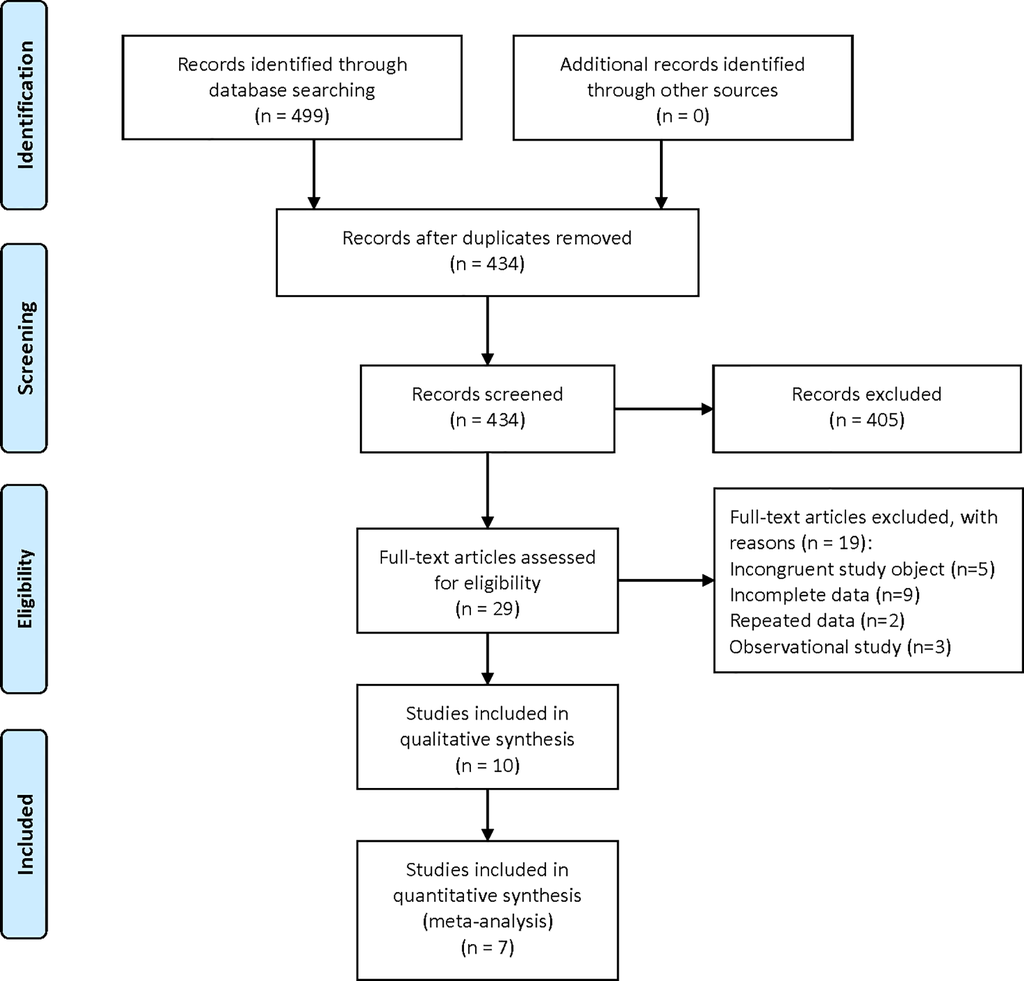

FIGURE 1 | Flowchart of study inclusion according to the PRISMA 2009 guidelines.

(p=0.10; Supplementary Figure 8). However, in the peripheral

tissues, the percentage of CD3<sup>+</sup>T lymphocytes (including in the

ears, blood, and spleen) decreased signiﬁcantly after treatment with

S1PR agonists (MD: −10.35; 95% CI: −15.19 to −5.51; p<0.0001;

Supplementary Figure 9). We also found that the number of white

blood cells (WBCs) was markedly reduced (MD: −1.67; 95% CI:

−3.20 to −0.15; p=0.03; Supplementary Figure 10) relative to the

control group. The details are listed in Table 3.

SPHK1/2

Shin et al. (27) reported that, after treatment with Ceranib-2 or

MP-A08, IL-17A, IL-17F, and TNF-a levels were signiﬁcantly

decreased (p<0.05) compared with those in IMQ-induced skin

inﬂammation. Levels of keratinocyte hyperproliferation markers

K6 and K16 were also signiﬁcantly suppressed (p<0.05). A meta-

analysis showed that SPHK2 inhibitors reduced spleen weight

(MD: −0.03; 95% CI: −0.06 to −0.00; p=0.03; Supplementary

Figure 11) and spleen cell numbers (MD: −24.88; 95% CI: −35.27

to −14.48; p<0.00001; Supplementary Figure 12). However, the

number of lymph nodes did not signiﬁcantly decrease (p>0.05;

Supplementary Figure 13). The details are listed in Table 3.

DISCUSSION

To our knowledge, this is the ﬁrst systematic review and meta-

analysis of clinical and preclinical animal studies to evaluate the

efﬁcacy and mechanism of S1P and its signal modulators for

treating psoriasis and psoriasis-like mice (Figure 2). This study

mainly included literature of clinical and preclinical research. In

the preclinical research section, we subdivided the basic research

of S1P and its modulators for psoriasis into phenotypes and

mechanisms for the meta-analysis. In this study, we classiﬁed

intervention drugs into S1PR agonists, SPHK inhibitors, and S1P

lyases according to their different roles in the SIP signaling

pathway. The S1PR agonists in this systematic review included

TABLE 1 | Characteristics of the included preclinical studies.

Study

Author and

Year

Drug(s)

Species

Sex/Age/

Weight

Psoriasis

Model

Intervention

Group

Control

Group

Administration

Route

Outcomes

Schaper et al.,

2013 (23)

FTY720

BALB/c

Female/6–

8 w

50 mg, 5% IMQ

1. IMQ

+FTY720

IMQ

+vehicle

Intraperitoneal

HE (ET, PCNA), ICI, EE, IL-17,

IL-23, LNW, LNCC, WBC,

Lymphocytes

S1p

2. IMQ+S1p

IMQ

+vehicle

HE (ET, PCNA), ICI, EE, IL-17,

IL-23, LNW, LNCC, WBC,

Lymphocytes, ES

Sun, 2017 (24)

FTY720

BALB/c

Female/6–

8 w

62.5 mg, 5% IMQ

IMQ+FTY720

IMQ

Intraperitoneal

HE

Ji et al., 2018

(25)

FTY720

Kunming

mice

Female/

6–8 w

0.2 mg diethylstilbestrol

1. FTY720

Vehicle

Oral

Mitotic index;

Syl930

2. Syl930

Vehicle

Mitotic index; Body weight

Guinea

pigs

Female

5% (m/v) propranolol ethanol

solution containing azone and

propanediol (1:3)

3. Syl930

Vehicle

HE (PS), Body weight

Shin et al., 2019

(27)

Ceranib-2/

MP-A08

C57BL/6

Male/8 w

83 mg, 5% IMQ

IMQ

+Ceranib-2

IMQ+MP-A08

IMQ

+EPH

Topical

PASI (erythema, scaling, skin

thickness), LNCC, SpCC, SpW,

IL-17A, K6, K16

PF-543/

ABC294640

IMQ+ PF-

543,

IMQ

+ABC294640

IMQ

+EPH

PASI (erythema, scaling, skin

thickness), LNCC, SpCC, SpW

Qin and Zheng,

2019 (26)

FTY720

C57BL/6

Female

10 mg/d IMQ

IMQ+FTY720

IMQ

+PBS

Intraperitoneal

EaT, CD3<sup>+</sup>T cells

Jeon et al., 2020

(28)

SLI

BALB/c

8 w

62.5 mg, 5% IMQ

IMQ+ SLI

IMQ

Subcutaneous

HE (ET), PASI (erythema,

scaling, skin thickness), EaT

Jing et al., 2020

(29)

FTY720

IMMH002

BALB/c

Female/6–

8 w

50 mg, 5% IMQ

1. IMQ

+FTY720

IMQ+

Vehicle

Oral

PASI (erythema, scaling, skin

thickness)

2. IMQ

+IMMH002

IMQ+

Vehicle

PASI (erythema, scaling, skin

thickness), CD3<sup>+</sup>T cells

Hartley

guinea

pigs

Female/4–

6 w/250–

400 g

5% propranolol in emulsifying

ointment

3. FTY720

Vehicle

PS, ET, PCNA

4. IMMH002

Vehicle

PS, ET, PCNA, IL-17

Shin et al., 2020

(30)

HWG-35D

C57BL/6

Male/8 w

83 mg, 5% IMQ

IMQ+ HWG-

35D

IMQ

+EPH

(H2O)

Topical

PASI (erythema, scaling, skin

thickness), LNCC, SpCC, SpW,

IL-17A,/K6, K16

Okura et al.,

2021 (31)

Fingolimod

(FTY720)

BALB/c

Female/7–

9 w

30 mg, 5% IMQ

IMQ+

Fingolimod

IMQ

+PBS

Intraperitoneal

PASI, ET, CD3<sup>+</sup>T cells

CLA, cutaneous lymphocyte-associated antigen; DC, dendritic cells; EaT, ear thickness; EE, edema-ear; ES, ear swelling; ET, epidermal thickening; HE, hematoxylin-eosin staining; ICI,

inﬂammatory cell inﬂux; IMQ, imiquimod; LC, Langerhans cells; LNCC, lymph node cell count; LNW, lymph node weight; PCNA, proliferating cell nuclear antigen; PS, pathology score; S1P,

sphingosine-1-phosphate; SL1, S1P lyase-speciﬁc inhibitor; SpCC, spleen cell count; SpW, spleen weight; WBC, white blood cell; w, weeks.

S1P, FTY720, Syl930, and IMMH002. FTY720, also known as

ﬁngolimod, is an analog of S1P derived from the structure-

modiﬁed extract of Cordyceps sinensis. It is the ﬁrst S1PR

modulator approved by the US Food and Drug Administration

for the treatment of relapsing multiple sclerosis (32). FTY720

binds to four of ﬁve S1PRs (S1PR1, S1PR3, S1PR4, S1PR5) to

reduce the number of lymphocytes in the blood and inhibit the

inﬁltration of inﬂammatory cells (13). Syl930 and IMMH002,

developed by a Chinese team, are selective S1PR1 modulators,

such as FTY720, that regulate the distribution of lymphocytes by

inducing lymphocyte homing to treat psoriasis (29).

In patients with psoriasis, the serum concentration of S1P

increases (16). Shin et al. used Ceranib-2, a ceramidase inhibitor,

andMP-A08,anSPHK1/2inhibitor, toprevent S1Psynthesis. They

found that topical inhibition of S1P production improves

inﬂammation in psoriasis-like mice, possibly by blocking Th17

cell differentiation (27). In particular, SPHK2 inhibitors such as

ABC294640 and HWG-35D have the greatest inhibitory effect on

S1P synthesis (27, 30). Several studies have reported that S1P

induces keratinocyte differentiation (33, 34). Jeon et al. used an

SLI to inhibit S1P lyase activity in human keratinocytes and

observed the same phenomenon. In addition, the severity of

psoriasis-like dermatitis in mice is alleviated (28). Our ﬁndings

point to the improvement of psoriasis by inhibiting S1P expression

or synthesis. Only clinical study to date has reported on the clinical

efﬁcacy and safety of S1PR. It is recommended that 20 mg

TABLE 2 | Phenotypes of S1P signal modulators for treating psoriasis.

Study or subgroup

Experiment

Control

Mean difference [95% CI]

I²

P value

Mean

SD

Total

Mean

SD

Total

1. S1PR agonists

1.1

PASI scores

Jing et al., 2020-1 (29)

5.26

1.14

10

7.26

1.14

10

-2.00 [-3.00, -1.00]

Jing et al., 2020-2 (29)

5.02

1.28

10

7.26

1.28

10

-2.24 [-3.36, -1.12]

Okura et al., 2021 (31)

4.95

1.25

5

7.60

1.25

5

-2.65 [-4.20, -1.10]

Subtotal (95% CI)

25

25

-2.21 [-2.88, -1.54]

0%

<0.00001

1.2 PASI-Erythema

Jing et al., 2020-1 (29)

1.21

0.45

10

1.99

0.45

10

-0.78 [-1.17, -0.39]

Jing et al., 2020-2 (29)

0.87

0.64

10

1.99

0.64

10

-1.12 [-1.68, -0.56]

Subtotal (95% CI)

20

20

-0.89 [-1.22, -0.57]

0%

<0.00001

1.3 PASI-Thickness

Jing et al., 2020-1 (29)

2.17

0.50

10

2.82

0.50

10

-0.65 [-1.09, -0.21]

Jing et al., 2020-2 (29)

2.16

0.51

10

2.82

0.51

10

-0.66 [-1.11, -0.21]

Subtotal (95% CI)

20

20

-0.65 [-0.97, -0.34]

0%

<0.0001

1.4

Ear swelling

Qin and Zheng, 2019 (26)

0.30

0.20

6

0.34

0.20

6

-0.04 [-0.27, 0.19]

Schaper et al., 2013-2 (23)

0.09

0.02

6

0.15

0.03

6

-0.06 [-0.09, -0.03]

Subtotal (95% CI)

12

12

-0.06 [-0.09, -0.03]

0%

<0.0001

1.5

HE pathology score

Ming et al., 2018-3 (25)

0.31

0.20

5

2.82

0.53

5

-2.51 [-3.01, -2.01]

Jing et al., 2020-3 (29)

0.89

0.34

8

2.26

0.46

8

-1.37 [-1.77, -0.97]

Jing et al., 2020-4 (29)

0.37

0.32

8

2.26

0.46

8

-1.89 [-2.28, -1.50]

Subtotal (95% CI)

21

21

-1.91 [-2.52, -1.30]

84%

<0.00001

1.6

HE Epidermal thickness

Jing et al., 2020-3 (29)

80.30

8.12

8

108.27

7.22

8

-27.97 [-35.50, -20.44]

Jing et al., 2020-4 (29)

67.67

6.77

8

108.27

7.22

8

-40.60 [-47.46, -33.74]

Okura et al., 2021 (31)

138.14

28.46

5

228.87

28.46

5

-90.73 [-126.01, -55.45]

Schaper et al., 2013-1 (23)

62.22

4.68

6

58.25

5.85

6

3.97 [-2.02, 9.96]

Schaper et al., 2013-2 (23)

53.57

9.36

6

58.25

5.85

6

-4.68[-13.51, 4.15]

Subtotal (95% CI)

33

33

-27.42 [-48.69, -6.16]

97%

0.01

1.7

HE PCNA positive cells

Jing et al., 2020-3 (29)

56.25

1.47

8

79.41

1.10

8

-23.16 [-24.43, -21.89]

Jing et al., 2020-4 (29)

33.46

2.57

8

79.41

1.10

8

-45.95 [-47.89, -44.01]

Schaper et al., 2013-1 (23)

23.12

1.70

6

24.68

4.68

6

-1.56 [-5.54, 2.42]

Schaper et al., 2013-2 (23)

19.09

3.12

6

24.68

4.68

6

-5.59 [-10.09, -1.09]

Subtotal (95% CI)

28

28

-19.16 [-36.55, -1.76]

100%

0.03

Total (95% CI)

159

159

-6.80 [-8.23, -5.38]

99%

<0.00001

2. SPHK2 inhibitor

2.1 PASI scores

Shin et al., 2019 (27)

1.86

0.55

5

3.03

0.55

5

-1.17 [-1.85, -0.49]

Shin et al., 2020 (30)

5.13

0.74

5

7.50

0.74

5

-2.37 [-3.29, -1.45]

Subtotal (95% CI)

10

10

-1.73 [-2.90, -0.56]

76%

0.004

2.2 PASI-Erythema

Shin et al., 2019 (27)

2.03

0.28

5

2.93

0.28

5

-0.90 [-1.25, -0.55]

Shin et al., 2020 (30)

2.25

0.23

5

2.99

0.23

5

-0.74 [-1.03, -0.45]

Subtotal (95% CI)

10

10

-0.80 [-1.02, -0.58]

0%

<0.00001

2.3 PASI-Thickness

Shin et al., 2019 (27)

2.30

0.37

5

3.08

0.37

5

-0.78 [-1.24, -0.32]

Shin et al., 2020 (30)

1.81

0.32

5

2.83

0.32

5

-1.02 [-1.42, -0.62]

Subtotal (95% CI)

10

10

-0.92 [-1.22, -0.62]

0%

<0.00001

2.4 PASI-Scale

Shin et al., 2019 (27)

1.77

0.64

5

3.12

0.64

5

-1.35 [-2.14, -0.56]

Shin et al., 2020 (30)

1.67

0.13

5

2.08

0.13

5

-0.41 [-0.57, -0.25]

Subtotal (95% CI)

10

10

-0.80 [-1.70, 0.11]

81%

0.09

Total (95% CI)

40

40

-0.95 [-1.26, -0.65]

79%

<0.00001

CI, conﬁdence interval; HE, hematoxylin and eosin; PASI, Psoriasis Area and Severity Index; PCNA, proliferating cell nuclear antigen; S1PR, sphingosine-1-phosphate receptor; SPHK2,

sphingosine kinase 2.

ponesimod orally can achieve good efﬁcacy with fewer adverse

reactions. However, a recent meta-analysis reported that patients

receiving S1P modulators were at an increased risk of infection and

transient cardiovascular events (35). As these modulators can be

considered potential drugs for the treatment of psoriasis, future

large-scale clinical research on different dosage forms and chemical

modiﬁcations to reduce toxicity can be pursued. Additionally, S1P

signaling plays a complex role in different cells, and further studies

are needed to explain the mechanism underlying psoriasis.

This systematic review has some limitations. First, the

methodological quality of the enrolled animal studies was

low, and most had a high risk of selection bias. Second,

because there are few studies on the mechanism of S1P and

its signal modulators for psoriasis, the number of articles

included was limited, which reduced our ability to reach a

deﬁnitive conclusion. Third, the PASI score, the gold standard

method for evaluating improvement in psoriasis, was not used

in all studies.

TABLE 3 | Mechanisms of S1P signal modulators in treating psoriasis.

Study or subgroup

Experiment

Control

Mean difference[95%CI]

I²

P value

Mean

SD

Total

Mean

SD

Total

1. S1PR agonists

1.1 Ear lesions

1.1.1 Ear-Inﬂammatory cell inﬂux

Schaper et al., 2013-1 (23)

2.3

0.6

6

2.4

0.6

6

-0.10 [-0.78, 0.58]

Schaper et al., 2013-2 (23)

1.7

0.7

6

2.4

0.6

6

-0.70 [-1.44, 0.04]

Total (95%CI)

12

12

-0.38 [-0.97, 0.20]

27%

0.20

1.1.2 IL-17

Schaper et al., 2013-1 (23)

21

6

3

48

18

3

-27.00 [-48.47, -5.53]

Schaper et al., 2013-2 (23)

59

20

3

48

18

3

11.00 [-19.45, 41.45]

Total (95%CI)

6

6

-9.60 [-46.70, 27.51]

75%

0.61

1.1.3 IL-23

Schaper et al., 2013-1 (23)

7

6

6

10

4

6

-3.00 [-8.77, 2.77]

Schaper et al., 2013-2 (23)

5

3

6

10

4

6

-5.00 [-9.00, -1.00]

Total (95%CI)

12

12

-4.35 [-7.64, -1.06]

0%

0.009

1.2 White blood cells

Schaper et al., 2013-1 (23)

5.8

1.7

6

7.7

1.3

6

-1.90 [-3.61, -0.19]

Schaper et al., 2013-2 (23)

6.9

4.0

6

7.7

1.3

6

-0.80 [-4.17, 2.57]

Total (95%CI)

12

12

-1.67 [-3.20, -0.15]

0%

0.03

1.3 Lymph node

1.3.1 Lymph node weight (mg)

Schaper et al., 2013-1 (23)

4.2

0.8

6

7.0

2.5

6

-2.80 [-4.90, -0.70]

Schaper et al., 2013-2 (23)

4.9

1.5

6

7.0

2.5

6

-2.10 [-4.43, 0.23]

Total (95%CI)

12

12

-2.49 [-4.05, -0.93]

0%

0.002

1.3.2 Lymph node cell count (*10<sup>6</sup>)

Schaper et al., 2013-1 (23)

6.4

1.7

6

8.6

3.0

6

-2.20 [-4.96, 0.56]

Schaper et al., 2013-2 (23)

7.4

3.3

6

8.6

3.0

6

-1.20 [-4.77, 2.37]

Total (95%CI)

12

12

-1.83 [-4.01, 0.36]

0%

0.10

1.4 Lymphocytes in blood

Schaper et al., 2013-1 (23)

2.0

0.9

6

3.8

0.7

6

-1.80 [-2.71, -0.89]

Schaper et al., 2013-2 (23)

3.5

1.9

6

3.8

0.7

6

-0.30 [-1.92, 1.32]

Total (95%CI)

12

12

-1.21 [-2.64, 0.23]

60%

0.10

1.5 CD3<sup>+</sup>T cells in peripheral tissues

Qin and Zheng, 2019 (26)

6.63

0.54

6

14.34

1.38

6

-7.71 [-8.90, -6.52]

Jin Jing et al., 2020-2 (29)

3.75

0.92

10

9.76

1.23

10

Jin Jing et al., 2020-2-1 (29)

24.47

2.93

10

42.31

2.75

10

Total (95%CI)

26

26

-10.35 [-15.19, -5.51]

97%

<0.0001

2. SPHK2 Inhibitor

2.1 Spleen weight (g)

Shin et al., 2019 (27)

0.12

0.01

5

0.14

0.01

5

-0.02 [-0.03, -0.01]

Shin et al., 2020 (30)

0.14

0.02

5

0.19

0.02

5

-0.05 [-0.07, -0.03]

Total (95%CI)

10

10

-0.03 [-0.06, -0.00]

78%

0.03

2.2 Spleen cell number (*10<sup>6</sup>)

Shin et al., 2019 (27)

90.83

14.16

5

120.88

14.16

5

-30.05 [-47.60, -12.50]

Shin et al., 2020 (30)

52.60

10.41

5

74.68

10.41

5

-22.08 [-34.98, -9.18]

Total (95%CI)

10

10

-24.88 [-35.27, -14.48]

0%

<0.00001

2.3 Lymph node cell number (*10<sup>5</sup>)

Shin et al., 2019 (27)

368.16

70.41

5

517.57

70.41

5

-149.41 [-236.69, -62.13]

Shin et al., 2020 (30)

2.43

2.36

5

7.43

2.36

5

-5.00 [-7.93, -2.07]

Total (95%CI)

10

10

-5.16 [-8.09, -2.24]

90%

0.33

CONCLUSION

Our ﬁndings indicate that psoriasis can be treated by blocking

S1P activity by competitively binding to S1PR and inhibiting S1P

synthase activity (SPHK2 inhibitor) using a mechanism that is

related to decreased immune responses and inﬂammatory factor

levels. These drugs improve psoriatic dermatitis by decreasing

the immune response, such as by reducing the number of

immune cells including lymphocytes, and downregulating the

secretion of inﬂammatory factors.

DATA AVAILABILITY STATEMENT

The original contributions presented in the study are included in

the article/Supplementary Material. Further inquiries can be

directed to the corresponding authors.

AUTHOR CONTRIBUTIONS

XL and BL proposed and designed the study. They also obtained

funding support. JW, SZ, S-tC, H-jL, and X-yS retrieved and

selected the data. Y-qZ and M-ZJ extracted the data. YinL and

YR assessed the quality of all studies. LL, YiL, DY, and Y-qZ

performed the statistical analysis of all data. LL and JW drafted

the manuscript, and XL revised it.

FUNDING

This work was supported by the National Natural Science

Foundation of China (grant no. 81874470 and 82074427), the

National Key Research and Development Program of China

(grant no. 2018YFC1705301), the National Natural Science

Foundation of Shanghai (grant no. 19ZR1458700), and

Shanghai Pujiang Program (grant no. 2020PJD067).

SUPPLEMENTARY MATERIAL

The Supplementary Material for this article can be found online at:

https://www.frontiersin.org/articles/10.3389/ﬁmmu.2021.759276/

full#supplementary-material

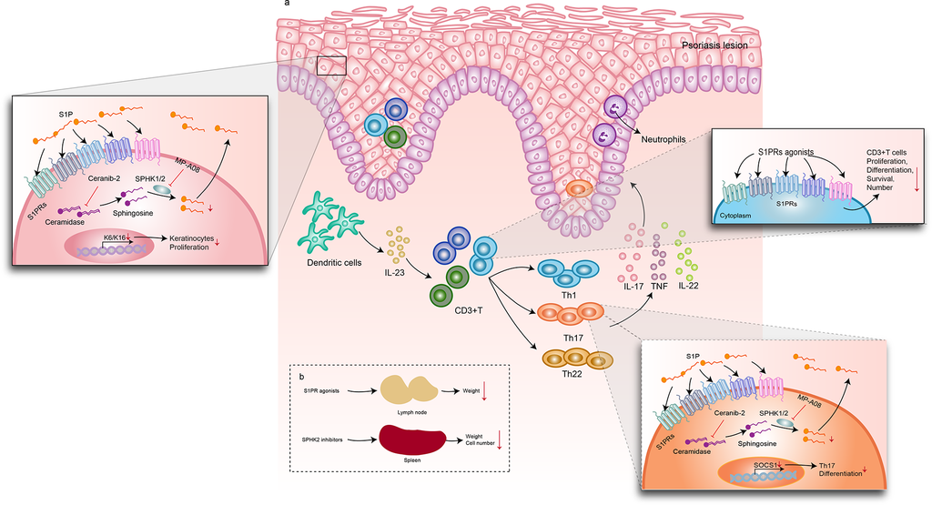

FIGURE 2 | Mechanisms of S1P signaling–related drugs in psoriasis-like dermatitis. S1PR agonists, including S1P, FTY720 (ﬁngolimod), SYl930, and IMMH002.

lymphocytes to produce abundant inﬂammatory factors, such as IL-17, IFN-g, TNF-a, and IL-22. These cytokines trigger excessive keratinocyte proliferation and

amplify psoriasis-related inﬂammation. When S1PR agonists were used, the numbers of WBCs and CD3<sup>+</sup>T cells decreased and IL-23 expression decreased. A

ceramidase inhibitor, Ceranib-2, and an SPHK1/2 inhibitor, MP-A08, suppressed S1P synthesis, resulting in decreased levels of IL-17A, IL-17F, and TNF-a in Th17

cells. In keratinocytes, Ceranib-2 and MP-A08 reduced the markers of keratinocyte hyperproliferation and keratins K6 and K16. Moreover, MP-A08 signiﬁcantly

suppressed SOCS1expression, which reduced the differentiation of Th17 cells. (A) Effect of S1P and its signal modulators on psoriatic skin lesions; (B) Effect of S1P

and its signal modulators on draining lymph nodes and spleen. DC, dendritic cells; KC, keratinocytes; S1P, sphingosine-1-phosphate; S1PR, sphingosine-1-

phosphate receptor; SPHK, sphingosine kinase; Th1, T helper 1; Th17, T helper 17; Th22, T helper 22.

Supplementary Figure 1 | Meta-analysis of the phenotype of psoriasis-like

dermatitis after treatment with an S1PR agonist. 95% CI, 95% conﬁdence interval;

S1PR, sphingosine-1-phosphate receptor

Supplementary Figure 2 | Meta-analysis of phenotype in psoriasis-like

dermatitis after treatment with an SPHK2 inhibitor. 95% CI, 95% conﬁdence

interval; SPHK2, sphingosine kinase 2.

Supplementary Figure 3 | Meta-analysis of IL-23 levels in psoriasis-like

dermatitis, after treatment with an S1PR agonist. 95% CI, 95% conﬁdence interval;

IL-23, interleukin-23; S1PR, sphingosine-1-phosphate receptor.

Supplementary Figure 4 | Meta-analysis of IL-17 levels in psoriasis-like

dermatitis after treatment with an S1PR agonist. 95% CI, 95% conﬁdence interval;

IL-17, interleukin-17; S1PR, sphingosine-1-phosphate receptor.

Supplementary Figure 5 | Meta-analysis of ear inﬂammatory cell inﬂux in

psoriasis-like dermatitis after treatment with an S1PR agonist. 95% CI, 95%

conﬁdence interval; S1PR, sphingosine-1-phosphate receptor

Supplementary Figure 6 | Meta-analysis of lymph node weight in psoriasis-like

dermatitis after treatment with an S1PR agonist. 95% CI, 95% conﬁdence interval;

S1PR, sphingosine-1-phosphate receptor.

Supplementary Figure 7 | Meta-analysis of lymph node cell counts in psoriasis-

like dermatitis after treatment with an S1PR agonist. 95% CI, 95% conﬁdence

interval; S1PR, sphingosine-1-phosphate receptor.

Supplementary Figure 8 | Meta-analysis of lymphocytes in blood in psoriasis-

like dermatitis after treatment with an S1PR agonist. 95% CI, 95% conﬁdence

interval; S1PR, sphingosine-1-phosphate receptor.

Supplementary Figure 9 | Meta-analysis of CD3<sup>+</sup>T cells in psoriasis-like

dermatitis after treatment with an S1PR agonist. 95% CI, 95% conﬁdence interval;

S1PR, sphingosine-1-phosphate receptor.

Supplementary Figure 10 | Meta-analysis of white blood cells in psoriasis-like

dermatitis after treatment with an S1PR agonist. 95% CI, 95% conﬁdence interval;

S1PR, sphingosine-1-phosphate receptor.

Supplementary Figure 11 | Meta-analysis of spleen weight in psoriasis-like

dermatitis after treatment with an SPHK2 inhibitor. 95% CI, 95% conﬁdence

interval; SPHK2, sphingosine kinase 2.

Supplementary Figure 12 | Meta-analysis of spleen cell numbers in psoriasis-

like dermatitis after treatment with an SPHK2 inhibitor. 95% CI, 95% conﬁdence

interval; SPHK2, sphingosine kinase 2.

Supplementary Figure 13 | Meta-analysis of lymph node cell numbers in

psoriasis-like dermatitis after treatment with an SPHK2 inhibitor. 95% CI, 95%

conﬁdence interval; SPHK2, sphingosine kinase 2.

REFERENCES

1. Boehncke W-H, Schön MP. Psoriasis. Lancet (2015) 386(9997):983–94.

doi: 10.1016/s0140-6736(14)61909-7

2. Parisi R, Symmons DP, Grifﬁths CE, Ashcroft DM. Global Epidemiology of

Psoriasis: A Systematic Review of Incidence and Prevalence. J Invest Dermatol

(2013) 133(2):377–85. doi: 10.1038/jid.2012.339

3. Rodriguez-Zuniga MJM, Garcia-Perdomo HA, Ortega-Loayza AG.

Association Between Hidradenitis Suppurativa and Metabolic Syndrome: A

Systematic Review and Meta-Analysis. Actas Dermosiﬁliogr (2019) 110

(4):279–88. doi: 10.1016/j.ad.2018.10.020

4. Li X, Miao X, Wang H, Wang Y, Li F, Yang Q, et al. Association of Serum Uric

Acid Levels in Psoriasis: A Systematic Review and Meta-Analysis. Med

(Baltimore) (2016) 95(19):e3676. doi: 10.1097/MD.0000000000003676

5. Li X, Kong L, Li F, Chen C, Xu R, Wang H, et al. Association Between

Psoriasis and Chronic Obstructive Pulmonary Disease: A Systematic Review

and Meta-Analysis. PloS One (2015) 10(12):e0145221. doi: 10.1371/

journal.pone.0145221

6. Hu SC, Lan CE. Psoriasis and Cardiovascular Comorbidities: Focusing on

Severe Vascular Events, Cardiovascular Risk Factors and Implications for

Treatment. Int J Mol Sci (2017) 18(10). doi: 10.3390/ijms18102211

7. Mahil SK, Capon F, Barker JN. Update on Psoriasis Immunopathogenesis and

Targeted Immunotherapy. Semin Immunopathol (2016) 38(1):11–27.

doi: 10.1007/s00281-015-0539-8

8. Ru Y, Ding X, Luo Y, Li H, Sun X, Zhou M, et al. Adverse Events Associated

With Anti-IL-23 Agents: Clinical Evidence and Possible Mechanisms. Front

Immunol (2021) 12:670398. doi: 10.3389/ﬁmmu.2021.670398

9. Krahel JA, Baran A, Kamiński TW, Maciaszek M, Flisiak I. Methotrexate

Decreases the Level of PCSK9-A Novel Indicator of the Risk of

Proatherogenic Lipid Proﬁle in Psoriasis. The Preliminary Data. J Clin Med

(2020) 9(4). doi: 10.3390/jcm9040910

10. Pietrzak A, Chabros P, Grywalska E, Kiciński P, Pietrzak-Franciszkiewicz K,

Krasowska D, et al. Serum Lipid Metabolism in Psoriasis and Psoriatic

Arthritis - An Update. Arch Med Sci AMS (2019) 15(2):369–75.

doi: 10.5114/aoms.2018.74021

11. Maceyka M, Spiegel S. Sphingolipid Metabolites in Inﬂammatory Disease.

Nature (2014) 510(7503):58–67. doi: 10.1038/nature13475

12. Cartier A, Hla T. Sphingosine 1-Phosphate: Lipid Signaling in Pathology and

Therapy. Science (2019) 366(6463):eaar5551. doi: 10.1126/science.aar5551

13. Baeyens AAL, Schwab SR. Finding a Way Out: S1P Signaling and Immune

Cell Migration. Annu Rev Immunol (2020) 38:759–84. doi: 10.1146/annurev-

immunol-081519-083952

14. Cohen JA, Barkhof F, Comi G, Hartung HP, Khatri BO, Montalban X, et al. Oral

Fingolimod or Intramuscular Interferon for Relapsing Multiple Sclerosis. N Engl

J Med (2010) 362(5):402–15. doi: 10.1056/NEJMoa0907839

15. Van Doorn R, Van Horssen J, Verzijl D, Witte M, Ronken E, Van Het Hof B,

et al. Sphingosine 1-Phosphate Receptor 1 and 3 Are Upregulated in Multiple

Sclerosis Lesions. Glia (2010) 58(12):1465–76. doi: 10.1002/glia.21021

16. Mysliwiec H, Baran A, Harasim-Symbor E, Choromanska B, Mysliwiec P,

Milewska AJ, et al. Increase in Circulating Sphingosine-1-Phosphate and

Decrease in Ceramide Levels in Psoriatic Patients. Arch Dermatol Res (2017)

309(2):79–86. doi: 10.1007/s00403-016-1709-9

17. Vaclavkova A, Chimenti S, Arenberger P, Holló P, Sator PG, Burcklen M, et al.

Oral Ponesimod in Patients With Chronic Plaque Psoriasis: A Randomised,

Double-Blind, Placebo-Controlled Phase 2 Trial. Lancet (2014) 384

(9959):2036–45. doi: 10.1016/S0140-6736(14)60803-5

18. Gisondi P, Fostini AC, Fossa I, Girolomoni G, Targher G. Psoriasis and the

Metabolic Syndrome. Clin Dermatol (2018) 36(1):21–8. doi: 10.1016/

j.clindermatol.2017.09.005

19. Moher D, Liberati A, Tetzlaff J, Altman DG, Altman D, Antes G, et al.

Preferred Reporting Items for Systematic Reviews and Meta-Analyses: The

PRISMA Statement. PLoS Med (2009) 6:e1000097. doi: 10.1371/

journal.pmed.1000097

20. Rohatgi A. WebPlotDigitizer [Online] (2019). Available at: https://automeris.

io/WebPlotDigitizer.

21. Burda BU, O'Connor EA, Webber EM, Redmond N, Perdue LA. Estimating

Data From Figures With a Web-Based Program: Considerations for a Systematic

Review. Res Synth Methods (2017) 8(3):258–62. doi: 10.1002/jrsm.1232

22. Hooijmans CR, Rovers MM, de Vries RB, Leenaars M, Ritskes-Hoitinga M,

Langendam MW. SYRCLE's Risk of Bias Tool for Animal Studies. BMC Med

Res Methodol (2014) 14:43. doi: 10.1186/1471-2288-14-43

23. Schaper K, Dickhaut J, Japtok L, Kietzmann M, Mischke R, Kleuser B, et al.

Sphingosine-1-Phosphate Exhibits Anti-Proliferative and Anti-Inﬂammatory

Effects in Mouse Models of Psoriasis. J Dermatol Sci (2013) 71(1):29–36.

doi: 10.1016/j.jdermsci.2013.03.006

24. Sun Y-Q. Experimental Study on Anti-Inﬂammatory Treatment of Psoriasis

Targeting STAT3[Master's Degree]. Nanjing, JIangsu Province: Nanjing

Medical University (2017).

25. Ji M, Xue N, Lai F, Zhang X, Zhang S, Wang Y, et al. Validating a Selective S1P

(1) Receptor Modulator Sy1930 for Psoriasis Treatment. Biol Pharm Bull

(2018) 41(4):592–6. doi: 10.1248/bpb.b17-00939

26. Qin H, Zheng J. Effect of the Sphingosine-1-Phosphate Receptor Antagonist

FTY720 on gdt Cells in the Skin of Imiquimod-Induced Psoriasis-Like Mouse

Model. Chin J Dermatol (2019) 52(6):395–400. doi: 10.3760/

cma.j.issn.0412⁃4030.2019.06.005

27. Shin SH, Cho KA, Hahn S, Lee Y, Kim YH, Woo SY, et al. Inhibiting Sphingosine

Kinase 2 Derived-Sphingosine-1-Phosphate Ameliorates Psoriasis-Like Skin

Disease via Blocking Th17 Differentiation of Naive CD4 T Lymphocytes in

Mice. Acta Derm Venereol (2019) 99(6):594–601. doi: 10.2340/00015555-3160

28. Jeon S, Song J, Lee D, Kim GT, Park SH, Shin DY, et al. Inhibition of

Sphingosine 1-Phosphate Lyase Activates Human Keratinocyte

Differentiation and Attenuates Psoriasis in Mice. J Lipid Res (2020) 61

(1):20–32. doi: 10.1194/jlr.RA119000254

29. Jing J, Nina X, Yuan L, Rong F, Mingjin W, Ming J, et al. A Novel S1P1

Modulator IMMH002 Ameliorates Psoriasis in Multiple Animal Models. Acta

Pharm Sinica B (2020) 10(2):276–88. doi: 10.1016/j.apsb.2019.11.006

30. ShinSH,KimHY,YoonHS,ParkWJ,AdamsDR,PyneNJ,etal.ANovelSelective

Sphingosine Kinase 2 Inhibitor, HWG-35d, Ameliorates the Severity of

Imiquimod-Induced Psoriasis Model by Blocking Th17 Differentiation of Naïve

CD4 T Lymphocytes. IntJ Mol Sci (2020) 21(21):8371 doi:10.3390/ijms21218371

31. Okura I, Kamata M, Asano Y, Mitsui A, Shimizu T, Sato S, et al. Fingolimod

Ameliorates Imiquimod-Induced Psoriasiform Dermatitis by Sequestrating

Interleukin-17-Producing gd T Cells in Secondary Lymph Nodes. J Dermatol

Sci (2021) 102(2):116–25. doi: 10.1016/j.jdermsci.2021.04.004

32. Brinkmann V, Billich A, Baumruker T, Heining P, Schmouder R, Francis G,

et al. Fingolimod (FTY720): Discovery and Development of an Oral Drug to

Treat Multiple Sclerosis. Nat Rev Drug Discov (2010) 9(11):883–97.

doi: 10.1038/nrd3248

33. Vogler R, Sauer B, Kim DS, Schäfer-Korting M, Kleuser B. Sphingosine-1-

Phosphate and its Potentially Paradoxical Effects on Critical Parameters of

Cutaneous Wound Healing. J Invest Dermatol (2003) 120(4):693–700.

doi: 10.1046/j.1523-1747.2003.12096.x

34. Schüppel M, Kürschner U, Kleuser U, Schäfer-Korting M, Kleuser B.

Sphingosine 1-Phosphate Restrains Insulin-Mediated Keratinocyte

Proliferation via Inhibition of Akt Through the S1P2 Receptor Subtype.

J Invest Dermatol (2008) 128(7):1747–56. doi: 10.1038/sj.jid.5701259

35. Lasa JS, Olivera PA, Bonovas S, Danese S, Peyrin-Biroulet L. Safety of S1P

Modulators in Patients With Immune-Mediated Diseases: A Systematic

Review and Meta-Analysis. Drug Saf (2021) 44(6):645–60. doi: 10.1007/

s40264-021-01057-z

Conﬂict of Interest: The authors declare that the research was conducted in the

absence of any commercial or ﬁnancial relationships that could be construed as a

potential conﬂict of interest.

Publisher’s Note: All claims expressed in this article are solely those of the authors

and do not necessarily represent those of their afﬁliated organizations, or those of

the publisher, the editors and the reviewers. Any product that may be evaluated in

this article, or claim that may be made by its manufacturer, is not guaranteed or

endorsed by the publisher.

Copyright © 2021 Liu, Wang, Li, Zhang, Jin, Chen, Sun, Zhou, Lu, Yang, Luo, Ru, Li

and Li. This is an open-access article distributed under the terms of the Creative

Commons Attribution License (CC BY). The use, distribution or reproduction in other

forums is permitted, provided the original author(s) and the copyright owner(s) are

credited and that the original publication in this journal is cited, in accordance with

accepted academic practice. No use, distribution or reproduction is permitted which

does not comply with these terms.